# R语言ggplot2基础教程

## 分面：在一个图中画出多个图

这次用到mpg数据集，在ggplot2中自带。

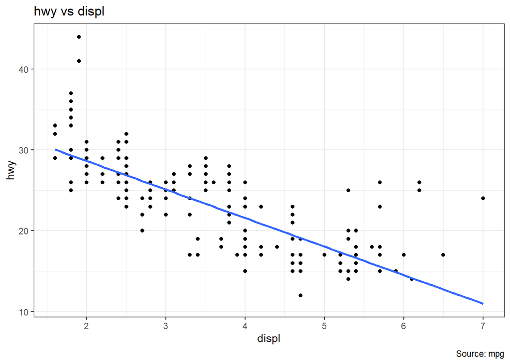

```r
library(ggplot2)
data(mpg, package="ggplot2")

g <- ggplot(mpg, aes(x=displ, y=hwy)) +
      geom_point() +
      labs(title="hwy vs displ", caption = "Source: mpg") +
      geom_smooth(method="lm", se=FALSE) +
      theme_bw()  # apply bw theme
plot(g)
```

我们得到一个简单的高速公路里程数（hwy）与发动机排量（ displ）图表。但如果想研究不同级别的车辆的这种关系如何变化呢？

### facet_wrap

facet_wrap()用于将一个大区分解成多个小的小区，用于单个分类。它以一个公式作为主参数。~左边的项目构成了行，右边的项目构成了列。

默认情况下，所有的小图在X轴和Y轴上的比例都是相同的。你可以通过设置scales=’free’来设置它们的自由度，但是这种方式可能会增加组间比较的难度。

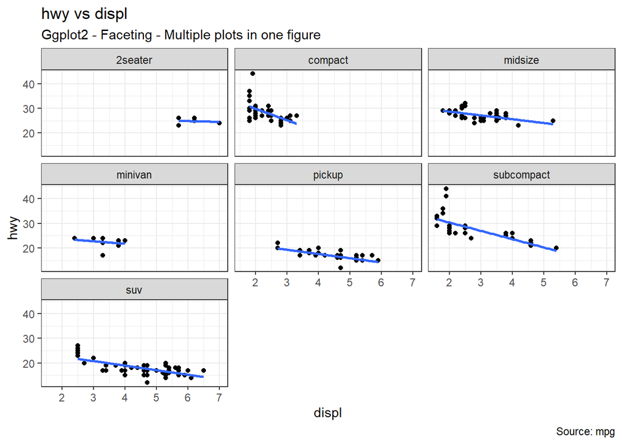

```r
library(ggplot2)
g <- ggplot(mpg, aes(x=displ, y=hwy)) +
      geom_point() +
      geom_smooth(method="lm", se=FALSE) +
      theme_bw()  # apply bw theme

# 正常xy轴范围
g + facet_wrap( ~ class, nrow=3) + labs(title="hwy vs displ", caption = "Source: mpg", subtitle="Ggplot2 - Faceting - Multiple plots in one figure")  # 共享的范围
```

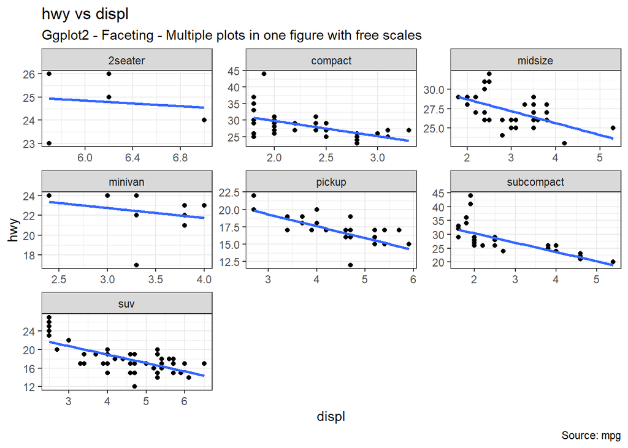

```r
# 自动调整的xy轴范围
g + facet_wrap( ~ class, scales = "free") + labs(title="hwy vs displ", caption = "Source: mpg", subtitle="Ggplot2 - Faceting - Multiple plots in one figure with free scales")  # 自定义范围
```

那么，你能从中推断出什么呢？其一，大多数两座车的发动机排量较大，而微型车和紧凑型车的发动机排量则偏低。这一点，从沿X轴上的点的位置就可以看出。

另外，随着发动机排量的增加，所有车型的公路行驶里程都会下降。这种下降在紧凑型车和超小型车中似乎更为明显。

### 方格网

如果嫌中间和底部行的标题占用空间。facet_grid()就可以去掉它，让图表有更多的空间去展示。facet_grid的主要区别在于不能选择网格中的行数和列数。

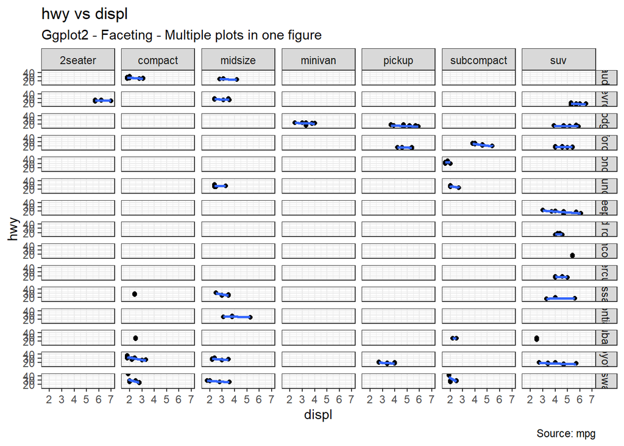

```r
library(ggplot2)

g <- ggplot(mpg, aes(x=displ, y=hwy)) +
      geom_point() +
      labs(title="hwy vs displ", caption = "Source: mpg", subtitle="Ggplot2 - Faceting - Multiple plots in one figure") +
      geom_smooth(method="lm", se=FALSE) +
      theme_bw()  # apply bw theme

# Add Facet Grid
g1 <- g + facet_grid(manufacturer ~ class)  # manufacturer in rows and class in columns
plot(g1)
```

下面用缸数再做一个grid

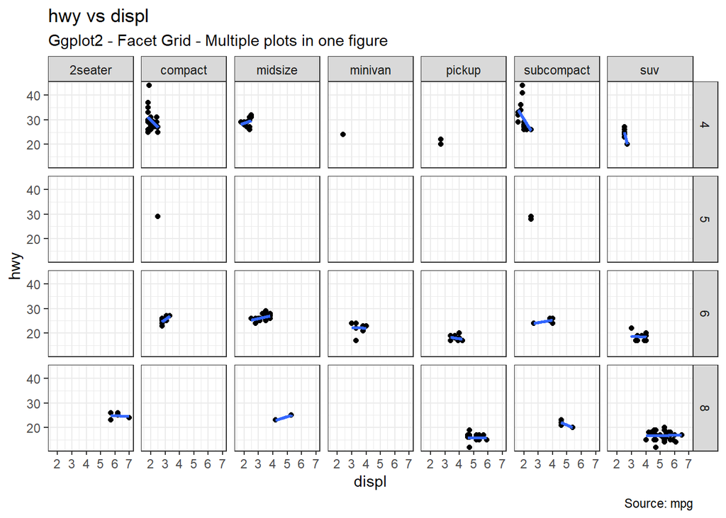

```r
library(ggplot2)

g <- ggplot(mpg, aes(x=displ, y=hwy)) +
      geom_point() +
      geom_smooth(method="lm", se=FALSE) +
      labs(title="hwy vs displ", caption = "Source: mpg", subtitle="Ggplot2 - Facet Grid - Multiple plots in one figure") +
      theme_bw()  # apply bw theme

# Add Facet Grid
g2 <- g + facet_grid(cyl ~ class)  # cyl in rows and class in columns.
plot(g2)
```

如果想把这两个图放在一起的话，可以用gridExtra包实现

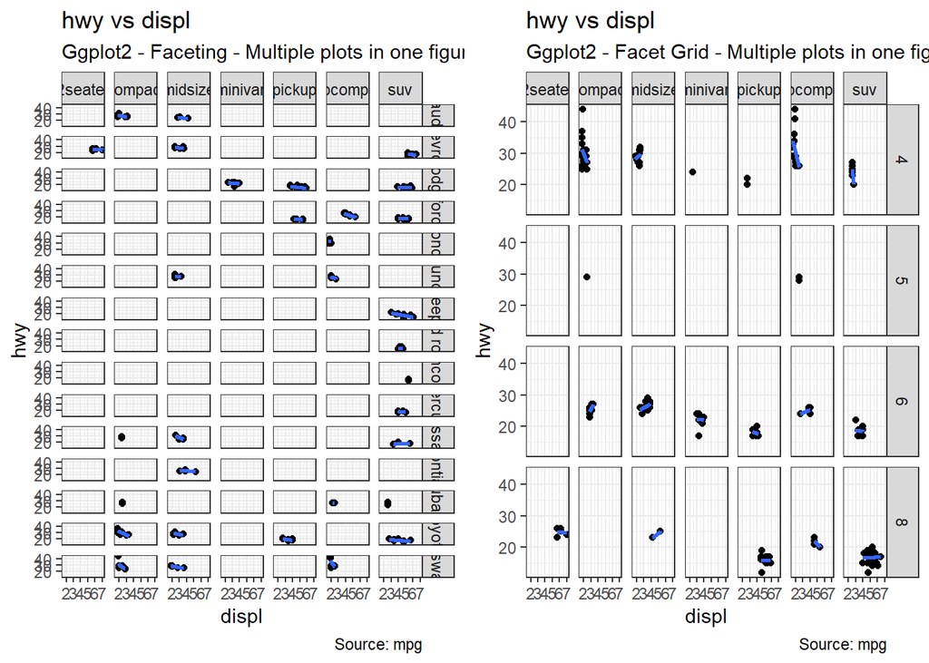

```r
library(gridExtra)
gridExtra::grid.arrange(g1, g2, ncol=2)
```

## 自定义画布背景、格网、边框等

### 如何设置画布背景

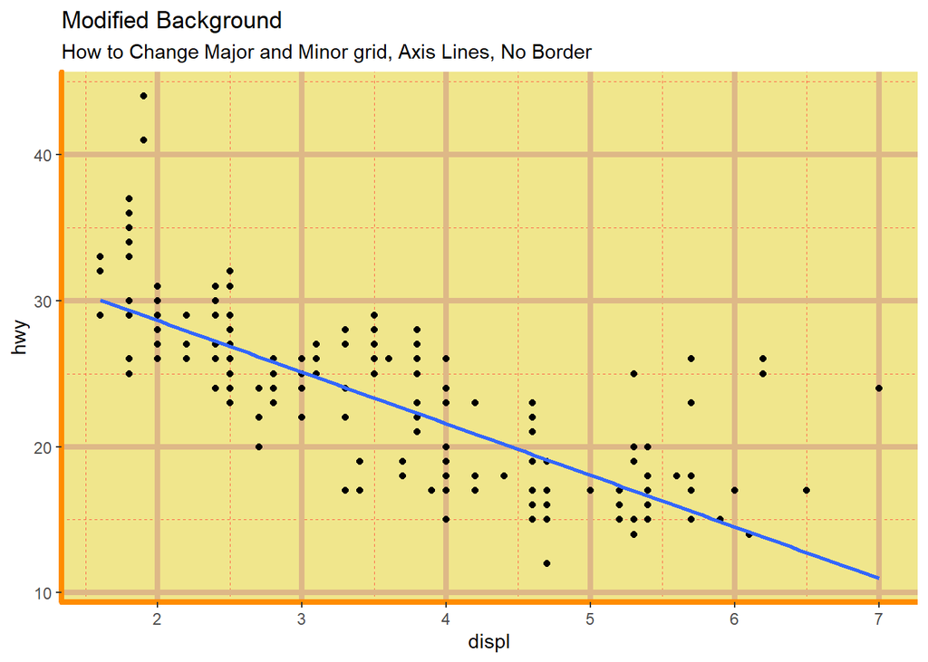

```r
library(ggplot2)

# Base Plot
g <- ggplot(mpg, aes(x=displ, y=hwy)) +
      geom_point() +
      geom_smooth(method="lm", se=FALSE) +
      theme_bw()  # apply bw theme


g + theme(panel.background = element_rect(fill = 'khaki'), #背景色
          panel.grid.major = element_line(colour = "burlywood", size=1.5), #主格网
          panel.grid.minor = element_line(colour = "tomato", #次格网
                                          size=.25,
                                          linetype = "dashed"),
          panel.border = element_blank(), #画布的边界线取消
          axis.line.x = element_line(colour = "darkorange", #定义轴线
                                     size=1.5,
                                     lineend = "butt"),
          axis.line.y = element_line(colour = "darkorange",
                                     size=1.5)) +
    labs(title="Modified Background",
         subtitle="How to Change Major and Minor grid, Axis Lines, No Border")
```

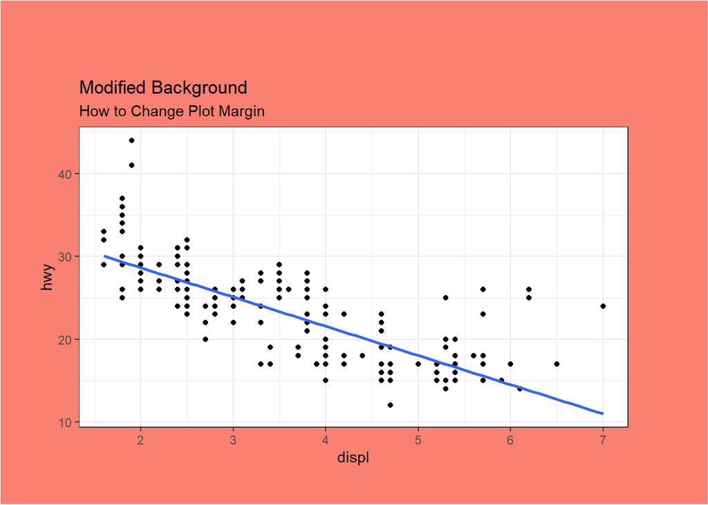

```r
# Change Plot Margins -----------------------------------------------
g + theme(plot.background=element_rect(fill="salmon"),
          plot.margin = unit(c(2, 2, 1, 1), "cm")) +  # 甚至可以设置画布的页边距
    labs(title="Modified Background", subtitle="How to Change Plot Margin")
```

ggplot中包含了600多种常用颜色，可以用colors()命令获取，并在作图中用color和fill等参数进行定义

### 如何删除主要和次要网格、更改边框、轴标题、文字和刻度线

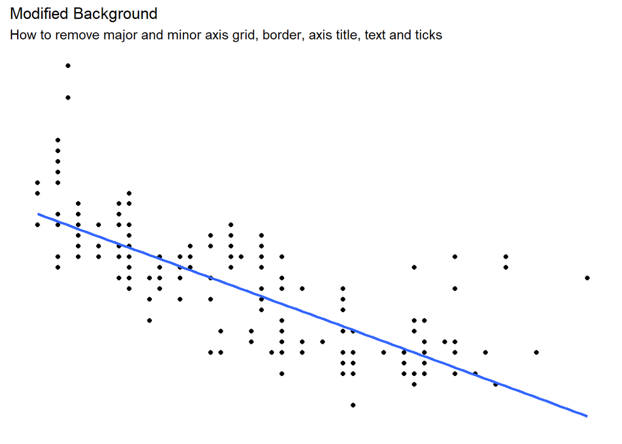

```r
library(ggplot2)

g <- ggplot(mpg, aes(x=displ, y=hwy)) +
      geom_point() +
      geom_smooth(method="lm", se=FALSE) +
      theme_bw()  # apply bw theme

g + theme(panel.grid.major = element_blank(), #对照着中英文意思。参数是element_blank()，用在theme中
          panel.grid.minor = element_blank(),
          panel.border = element_blank(),
          axis.title = element_blank(),
          axis.text = element_blank(),
          axis.ticks = element_blank()) +
  labs(title="Modified Background", subtitle="How to remove major and minor axis grid, border, axis title, text and ticks")
```

### 给画布添加一个背景图片

[figure not shown]

```r
library(ggplot2)
library(grid)
library(png)

img <- readPNG(system.file("img", "Rlogo.png", package="png")) # source: https://www.r-project.org/
g_pic <- rasterGrob(img, interpolate=TRUE)

g <- ggplot(mpg, aes(x=displ, y=hwy)) +
      geom_point() +
      geom_smooth(method="lm", se=FALSE) +
      theme_bw()  # apply bw theme

g + theme(panel.grid.major = element_blank(),
          panel.grid.minor = element_blank(),
          plot.title = element_text(size = rel(1.5), face = "bold"),
          axis.ticks = element_blank()) +
  annotation_custom(g_pic, xmin=5, xmax=7, ymin=30, ymax=45)
```